# IS 6489: Module 2 | Conley Fisheries

Meag Tessmann

29 Sept 2019

## Load packages and create empty data frame

```r
# Load packages
library(tidyverse)
# Define n
n <- 1000

# Empty data frame for 1000 simulated days
data <- data.frame(day = seq(1:n),
                demand = NA, # demand in Rockport
                quantity = NA, # quanity sold
                price = NA, # price per pound
                cost = 10000, # cost of daily operations
                earnings = NA)

head(data)
```

```
##   day demand quantity price  cost earnings
## 1   1     NA       NA    NA 10000       NA
## 2   2     NA       NA    NA 10000       NA
## 3   3     NA       NA    NA 10000       NA
## 4   4     NA       NA    NA 10000       NA
## 5   5     NA       NA    NA 10000       NA
## 6   6     NA       NA    NA 10000       NA
```

## Questions

### Q1

Plot simulated earnings.

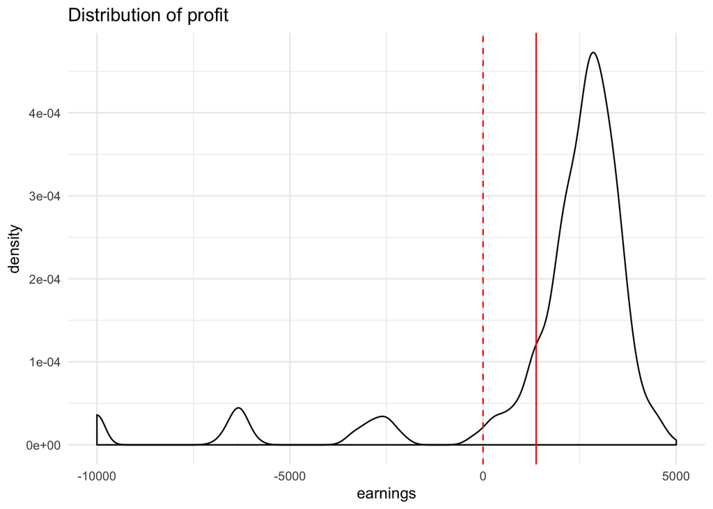

```r
# Define variables
set.seed(123)
boat_cost <- 10000
lbs_fish <- 3500
price_glou <- 3.25
rock_quant <- c(0, 1000, 2000, 3000, 4000, 5000, 6000)
rock_prob <- c(.02, .03, .05, .08, .33, .29, .22)
rock_demand_mu <- 3.65
rock_demand_sig <- .2

profit_glou <- price_glou*lbs_fish-boat_cost


# Fill in data with simulated values
data <- data %>%
  mutate(
    demand = sample(
      rock_quant,
      size=n,
      replace = T,
      prob = rock_prob),
    quantity = ifelse(demand <= lbs_fish, demand, lbs_fish),
    price = rnorm(n, rock_demand_mu, rock_demand_sig),
    earnings = price * quantity - boat_cost
  )


# Plot simulated values, with lines at breaking even and profit if only selling at glou

ggplot(data, aes(earnings)) +
  geom_density() +
  geom_vline(xintercept = 0, col = 2, lty = 2) +
  geom_vline(xintercept = profit_glou, col = 2) +
  theme_minimal()+
  labs(title = "Distribution of profit")
```

### Q2

What is P(F > 1375)?

.83

```r
# Calculate percentage of time earnings will be above 1375
(data$earnings > 1375) %>%
  mean
```

```
## [1] 0.83
```

### Q3

What is P(F < 0)

.097

```r
# Calculate percentage of time earnings will be a loss
(data$earnings < 0) %>%
  mean
```

```
## [1] 0.097
```

### Q4

What is the expected value (mean) of F?

1898.962

```r
# Calculate mean earnings
mean(data$earnings)
```

```
## [1] 1898.962
```

### Q5

What is your advice to Clint Conley? Write one paragraph in which you argue a position.

Clint,

I understand you’re debating whether to sell your daily catch at Gloucester or Rockport ports. Gloucester is a safe, steady bet if you feel more comfortable with having a gaurenteed daily cash flow.

If you have the savings and the stomach for a more volatile daily cash flow, I would suggest selling everyday at Rockport port. On average, you’ll make $524 more each day if you sell at Rockport than if you sell at Gloucester - that’s $191k more every year! Selling at Rockport will have it’s bad days, though. You’ll likely have to toss part of your catch about once per week and all of your catch about 7 days a year. Every other day, though, you’ll be earning over $2660 to make up for it.

Good luck.

```r
# summary for earnings & quantity
data$earnings %>%
  summary
```

```
##    Min. 1st Qu.  Median    Mean 3rd Qu.    Max.
##  -10000    1924    2661    1899    3166    5004
```

```r
data$quantity %>%
  summary
```

```
##    Min. 1st Qu.  Median    Mean 3rd Qu.    Max.
##       0    3500    3500    3257    3500    3500
```

```r
#Difference in means of two ports
mean(data$earnings) - profit_glou
```

```
## [1] 523.9621
```

```r
#Difference in means of two ports
(mean(data$earnings) - profit_glou)*365
```

```
## [1] 191246.2
```

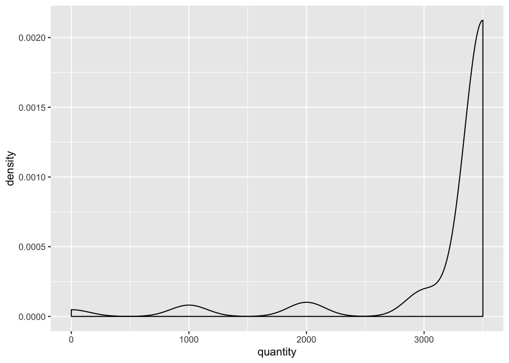

```r
# how often are fish being tossed?

ggplot(data, aes(quantity)) +
  geom_density()
```

```r
mean(data$quantity)
```

```
## [1] 3257
```

```r
# days per year tossing all
(data$quantity == 0) %>%
  mean * 365
```

```
## [1] 6.935
```

```r
# days per week tossing some
(data$quantity < 3500) %>%
  mean * 7
```

```
## [1] 1.148
```